# Final Project Analysis - Practical Machine Learning Course

Pasquale Grippo

18 August 2015

# Syllabus

These are the files produced during a homework assignment of Coursera’s MOOC Practical Machine Learning from Johns Hopkins University. For more information about the several MOOCs comprised in this Specialization, please visit: https://www.coursera.org/specialization/jhudatascience/

The scripts have been solely produced, tested and executed on MAC OS X 10.10.4, and RStudio Version 0.99.467.

Analyst: Pasquale Grippo

GitHub repo: https://github.com/PassiG/Practical-Machine-Learning-Course-Project

# Background Introduction

These are the files produced during a homework assignment of Coursera’s MOOC Practical Machine Learning from Johns Hopkins University. Here is the introduction of the exercise:

“Using devices such as Jawbone Up, Nike FuelBand, and Fitbit it is now possible to collect a large amount of data about personal activity relatively inexpensively. These type of devices are part of the quantified self movement ??? a group of enthusiasts who take measurements about themselves regularly to improve their health, to find patterns in their behavior, or because they are tech geeks. One thing that people regularly do is quantify how much of a particular activity they do, but they rarely quantify how well they do it. In this project, your goal will be to use data from accelerometers on the belt, forearm, arm, and dumbell of 6 participants. They were asked to perform barbell lifts correctly and incorrectly in 5 different ways. More information is available from the website here: http://groupware.les.inf.puc-rio.br/har (see the section on the Weight Lifting Exercise Dataset).”

Data Sources The training data for this project are available here:

https://d396qusza40orc.cloudfront.net/predmachlearn/pml-training.csv

The test data are available here:

https://d396qusza40orc.cloudfront.net/predmachlearn/pml-testing.csv

The data for this project comes from this original source: http://groupware.les.inf.puc-rio.br/har. If you use the document you create for this class for any purpose please cite them as they have been very generous in allowing their data to be used for this kind of assignment.

Please Note that I the code I use loads the data directly from the URL provided, so that you are not required to download the file to your environment. Please customize the code to your specific needs.

Project Intended Results The goal of your project is to predict the manner in which they did the exercise. This is the “classe” variable in the training set. You may use any of the other variables to predict with. You should create a report describing how you built your model, how you used cross validation, what you think the expected out of sample error is, and why you made the choices you did. You will also use your prediction model to predict 20 different test cases.

Your submission should consist of a link to a Github repo with your R markdown and compiled HTML file describing your analysis. Please constrain the text of the writeup to < 2000 words and the number of figures to be less than 5. It will make it easier for the graders if you submit a repo with a gh-pages branch so the HTML page can be viewed online (and you always want to make it easy on graders :-). You should also apply your machine learning algorithm to the 20 test cases available in the test data above. Please submit your predictions in appropriate format to the programming assignment for automated grading. See the programming assignment for additional details. Author initial note Please consult the explorAnalysis.R (in code/raw code) file in the gitHub repo in order to better understand the reasoning behind the tatics choosen. For instance and as a very simple example, the initial loading of data to memory involves assuming some values as NA. For obvious reasons, this is only possible after you have already pooked around the data initially.

# Reproduceablity

This chapter describes the steps to excecute in order to repreduce this analysis.

## Setup Environment

```r
#this functions just creates a structure into the directory for this porpose
#it expects to have a CourseraDataScience folder in the working directory. In case there is not such a directory then create it or adjust the code.
initEnv <- function(Projectname = "Practical Machnine Learninig: Peer Assessments : Course Project 1")
{
        setwd("~/CourseraDataScience")
        Projectwd <- paste(getwd(),Projectname,sep = "/")
        if(getwd()!= Projectwd)
        {
                if(!file.exists(paste("./",Projectname,sep = "")))
                {
                        dir.create(paste("./",Projectname,sep = ""))
                }
                setwd(Projectwd)
                if(!file.exists("./data"))
                {
                        dir.create("./data")
                }
        }
}

initEnv()
```

## Install Libraries

In order to reproduce the same results, you need a certain set of packages, as well as setting a pseudo random seed equal to the one I used.

The following Libraries were used for this project, which you should install - if not done yet - and load on your working environment.

```r
install.packages("rpart.plot")
install.packages("caret", dependencies = TRUE)
install.packages("rpart")
install.packages("rpart.plot")
install.packages("RColorBrewer")
install.packages("rattle")
install.packages("randomForest")
```

```r
library(caret)
```

```r
library(rpart)
library(rpart.plot)
library(RColorBrewer)
library(rattle)
library(randomForest)
```

Finally, set the same seed with the following line of code:

```r
set.seed(12345)
```

# Getting the data

The training data set can be found on the following URL: http://d396qusza40orc.cloudfront.net/predmachlearn/pml-training.csv" The testing data set can be found on the following URL: “http://d396qusza40orc.cloudfront.net/predmachlearn/pml-testing.csv”

You can use following function to download the data:

```r
getDataFiles <- function(filesDirectory = "./") {
        testUrl <- "http://d396qusza40orc.cloudfront.net/predmachlearn/pml-testing.csv"
        trainUrl <- "http://d396qusza40orc.cloudfront.net/predmachlearn/pml-training.csv"

        if (!file.exists(filesDirectory))
               {
               dir.create(filesDirectory)
               }

        trainFile <- "train.csv"
        testFile <- "test.csv"
        trainFilePath <- paste(filesDirectory, trainFile, sep = "/")
        testFilePath <- paste(filesDirectory, testFile, sep = "/")

        if (!file.exists(trainFilePath) || !file.exists(testFilePath))
        {
                download.file(trainUrl, destfile = trainFilePath, method="curl")
                download.file(testUrl, destfile = testFilePath, method="curl")
        }

        c(trainFilePath , testFilePath)
}
```

Run the function, for example, as follows:

```r
DataPaths <- getDataFiles("data")
```

Create two data frames with the downloaded data:

```r
training <- read.csv(DataPaths[1], na.strings=c("NA","#DIV/0!",""))
testing <- read.csv(DataPaths[2], na.strings=c("NA","#DIV/0!",""))
```

Partioning the training set into two Partioning Training data set into two data sets, 60% for myTraining, 40% for myTesting:

```r
inTrain <- createDataPartition(y=training$classe, p=0.6, list=FALSE)
myTraining <- training[inTrain, ];
myTesting <- training[-inTrain, ]
dim(myTraining);
```

```
## [1] 11776   160
```

```r
dim(myTesting)
```

```
## [1] 7846  160
```

# Cleaning the data

The following transformations were used to clean the data:

Transformation 1: Cleaning NearZeroVariance Variables Run this code to view possible NZV Variables:

```r
myDataNZV <- nearZeroVar(myTraining, saveMetrics=TRUE)
myDataNZV[ myDataNZV$nzv == TRUE,]
```

```
##                        freqRatio percentUnique zeroVar  nzv
## new_window              49.54077   0.016983696   FALSE TRUE
## kurtosis_yaw_belt        0.00000   0.000000000    TRUE TRUE
## skewness_yaw_belt        0.00000   0.000000000    TRUE TRUE
## amplitude_yaw_belt       0.00000   0.008491848    TRUE TRUE
## avg_roll_arm            47.00000   1.587975543   FALSE TRUE
## stddev_roll_arm         47.00000   1.587975543   FALSE TRUE
## var_roll_arm            47.00000   1.587975543   FALSE TRUE
## avg_pitch_arm           47.00000   1.587975543   FALSE TRUE
## stddev_pitch_arm        47.00000   1.587975543   FALSE TRUE
## var_pitch_arm           47.00000   1.587975543   FALSE TRUE
## avg_yaw_arm             47.00000   1.587975543   FALSE TRUE
## stddev_yaw_arm          49.00000   1.570991848   FALSE TRUE
## var_yaw_arm             49.00000   1.570991848   FALSE TRUE
## kurtosis_yaw_dumbbell    0.00000   0.000000000    TRUE TRUE
## skewness_yaw_dumbbell    0.00000   0.000000000    TRUE TRUE
## amplitude_yaw_dumbbell   0.00000   0.008491848    TRUE TRUE
## kurtosis_yaw_forearm     0.00000   0.000000000    TRUE TRUE
## skewness_yaw_forearm     0.00000   0.000000000    TRUE TRUE
## amplitude_yaw_forearm    0.00000   0.008491848    TRUE TRUE
## stddev_roll_forearm     47.00000   1.587975543   FALSE TRUE
## var_roll_forearm        47.00000   1.587975543   FALSE TRUE
## avg_pitch_forearm       44.00000   1.613451087   FALSE TRUE
## stddev_pitch_forearm    22.00000   1.604959239   FALSE TRUE
## var_pitch_forearm       44.00000   1.613451087   FALSE TRUE
## avg_yaw_forearm         44.00000   1.613451087   FALSE TRUE
## stddev_yaw_forearm      44.00000   1.613451087   FALSE TRUE
## var_yaw_forearm         44.00000   1.613451087   FALSE TRUE
```

```r
nzvNames <- rownames(myDataNZV[ myDataNZV$nzv == TRUE,])
nzvNames
```

```
##  [1] "new_window"             "kurtosis_yaw_belt"
##  [3] "skewness_yaw_belt"      "amplitude_yaw_belt"
##  [5] "avg_roll_arm"           "stddev_roll_arm"
##  [7] "var_roll_arm"           "avg_pitch_arm"
##  [9] "stddev_pitch_arm"       "var_pitch_arm"
## [11] "avg_yaw_arm"            "stddev_yaw_arm"
## [13] "var_yaw_arm"            "kurtosis_yaw_dumbbell"
## [15] "skewness_yaw_dumbbell"  "amplitude_yaw_dumbbell"
## [17] "kurtosis_yaw_forearm"   "skewness_yaw_forearm"
## [19] "amplitude_yaw_forearm"  "stddev_roll_forearm"
## [21] "var_roll_forearm"       "avg_pitch_forearm"
## [23] "stddev_pitch_forearm"   "var_pitch_forearm"
## [25] "avg_yaw_forearm"        "stddev_yaw_forearm"
## [27] "var_yaw_forearm"
```

Run this code to create another subset without NZV variables:

```r
myTraining <- myTraining[,!(names(myTraining) %in% nzvNames)]
#To check the new N?? of observations
dim(myTraining)
```

```
## [1] 11776   133
```

Transformation 2: Removing the first 6 system and ID columns of Dataset, so that it does not interfer with ML Algorithms:

```r
myTraining <- myTraining[,-(1:6)]
```

Transformation 3: Cleaning Variables with too many NAs. For Variables that have more than a 60% threshold of NA’s I’m going to leave them out:

```r
trainingV3 <- myTraining #creating another subset to iterate in loop
for(i in 1:length(myTraining)) { #for every column in the training dataset
        if( sum( is.na( myTraining[, i] ) ) /nrow(myTraining) >= .6 ) { #if n?? NAs > 60% of total observations
        for(j in 1:length(trainingV3)) {
            if( length( grep(names(myTraining[i]), names(trainingV3)[j]) ) ==1)  { #if the columns are the same:
                trainingV3 <- trainingV3[ , -j] #Remove that column
            }
        }
    }
}
dim(trainingV3)
```

```
## [1] 11776    53
```

```r
myTraining <- trainingV3
rm(trainingV3)
```

Now let us do the exact same 3 transformations but for our myTesting and testing data sets.

```r
clean1 <- colnames(myTraining)
clean2 <- colnames(myTraining[, -53]) #already with classe column removed
myTesting <- myTesting[clean1]
testing <- testing[clean2]
```

```r
#To check the new N?? of observations
dim(myTesting)
```

```
## [1] 7846   53
```

```r
#To check the new N?? of observations
dim(testing)
```

```
## [1] 20 52
```

```r
#Note: The last column - problem_id - which is not equal to training sets, was also "automatically" removed
```

In order to ensure proper functioning of Decision Trees and especially RandomForest Algorithm with the Test data set (data set provided), we need to coerce the data into the same type.

```r
for (i in 1:length(testing) ) {
        for(j in 1:length(myTraining)) {
        if( length( grep(names(myTraining[i]), names(testing)[j]) ) ==1)  {
            class(testing[j]) <- class(myTraining[i])
        }
    }
}
#And to make sure Coertion really worked, simple smart ass technique:
testing <- rbind(myTraining[2, -53] , testing) #note row 2 does not mean anything, this will be removed right.. now:
testing <- testing[-1,]
```

# Using ML algorithms for prediction: Decision Tree

```r
modFitA1 <- rpart(classe ~ ., data=myTraining, method="class")
```

Note: to view the decision tree with fancy run this command:

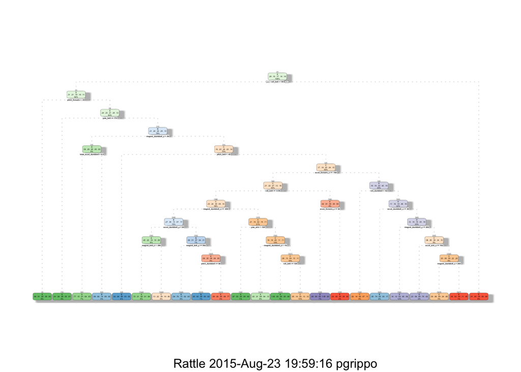

```r
fancyRpartPlot(modFitA1)
```

Predicting:

```r
predictionsA1 <- predict(modFitA1, myTesting, type = "class")
```

(Moment of truth) Using confusion Matrix to test results:

```r
confusionMatrix(predictionsA1, myTesting$classe)
```

```
## Confusion Matrix and Statistics
##
##           Reference
## Prediction    A    B    C    D    E
##          A 1879  260   30   69   66
##          B   56  759   88   34   54
##          C  105  340 1226  354  234
##          D  155  132   23  807   57
##          E   37   27    1   22 1031
##
## Overall Statistics
##
##                Accuracy : 0.7267
##                  95% CI : (0.7167, 0.7366)
##     No Information Rate : 0.2845
##     P-Value [Acc > NIR] : < 2.2e-16
##
##                   Kappa : 0.6546
##  Mcnemar's Test P-Value : < 2.2e-16
##
## Statistics by Class:
##
##                      Class: A Class: B Class: C Class: D Class: E
## Sensitivity            0.8418  0.50000   0.8962   0.6275   0.7150
## Specificity            0.9243  0.96334   0.8405   0.9441   0.9864
## Pos Pred Value         0.8155  0.76589   0.5427   0.6874   0.9222
## Neg Pred Value         0.9363  0.88928   0.9746   0.9282   0.9389
## Prevalence             0.2845  0.19347   0.1744   0.1639   0.1838
## Detection Rate         0.2395  0.09674   0.1563   0.1029   0.1314
## Detection Prevalence   0.2937  0.12631   0.2879   0.1496   0.1425
## Balanced Accuracy      0.8831  0.73167   0.8684   0.7858   0.8507
```

# Using ML algorithms for prediction: Random Forests

```r
 modFitB1 <- randomForest(classe ~. , data=myTraining)
```

Predicting in-sample error:

```r
predictionsB1 <- predict(modFitB1, myTesting, type = "class")
```

(Moment of truth) Using confusion Matrix to test results:

```r
confusionMatrix(predictionsB1, myTesting$classe)
```

```
## Confusion Matrix and Statistics
##
##           Reference
## Prediction    A    B    C    D    E
##          A 2229    7    0    0    0
##          B    3 1505    5    0    0
##          C    0    6 1363   16    2
##          D    0    0    0 1268    4
##          E    0    0    0    2 1436
##
## Overall Statistics
##
##                Accuracy : 0.9943
##                  95% CI : (0.9923, 0.9958)
##     No Information Rate : 0.2845
##     P-Value [Acc > NIR] : < 2.2e-16
##
##                   Kappa : 0.9927
##  Mcnemar's Test P-Value : NA
##
## Statistics by Class:
##
##                      Class: A Class: B Class: C Class: D Class: E
## Sensitivity            0.9987   0.9914   0.9963   0.9860   0.9958
## Specificity            0.9988   0.9987   0.9963   0.9994   0.9997
## Pos Pred Value         0.9969   0.9947   0.9827   0.9969   0.9986
## Neg Pred Value         0.9995   0.9979   0.9992   0.9973   0.9991
## Prevalence             0.2845   0.1935   0.1744   0.1639   0.1838
## Detection Rate         0.2841   0.1918   0.1737   0.1616   0.1830
## Detection Prevalence   0.2850   0.1928   0.1768   0.1621   0.1833
## Balanced Accuracy      0.9987   0.9951   0.9963   0.9927   0.9978
```

Random Forests yielded better Results, as expected!

# Generating Files to submit as answers for the Assignment:

Finally, using the provided Test Set out-of-sample error.

For Random Forests we use the following formula, which yielded a much better prediction in in-sample:

```r
predictionsB2 <- predict(modFitB1, testing, type = "class")
```

Function to generate files with predictions to submit for assignment

```r
pml_write_files = function(x){
  n = length(x)
  for(i in 1:n){
    filename = paste0("problem_id_",i,".txt")
    write.table(x[i],file=filename,quote=FALSE,row.names=FALSE,col.names=FALSE)
  }
}

pml_write_files(predictionsB2)
```